# Project 2: Data Mining, Classification, Prediction

### Cluster Analysis

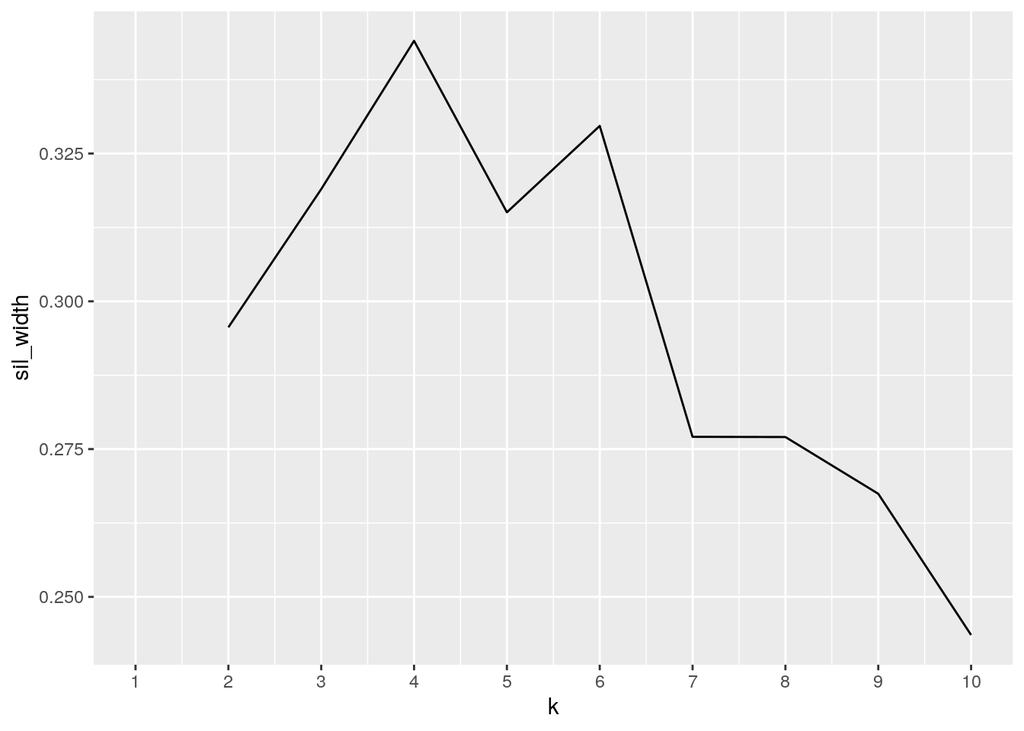

```r
library(cluster)
# CREATING CLUSTER
clustered <- abortion %>% select(poverty, aids, gonnorhea) %>%
    scale %>% as.data.frame
# DETERMINING SIL WIDTH FOR DIFFERENT NUMBER OF CLUSTERS
sil_width <- vector()
for (i in 2:10) {
    kms <- kmeans(clustered, centers = i)  #compute k-means solution for each k
    sil <- silhouette(kms$cluster, dist(clustered))  #get sil widths
    sil_width[i] <- mean(sil[, 3])  #take averages (higher is better)
}
ggplot() + geom_line(aes(x = 1:10, y = sil_width)) + scale_x_continuous(name = "k",
    breaks = 1:10)
```

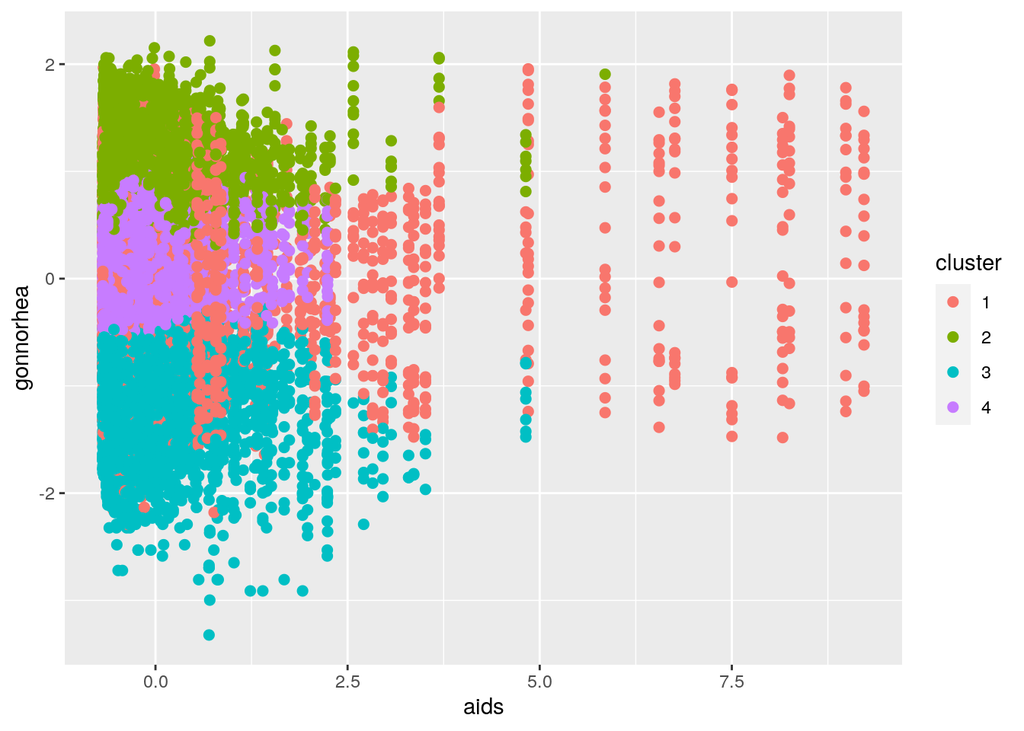

```r
# PAM
pam <- clustered %>% pam(4)
pamclust <- clustered %>% mutate(cluster = as.factor(pam$clustering))
# VISUALIZATION
pamclust %>% ggplot(aes(x = aids, y = gonnorhea, color = cluster)) +
    geom_point(size = 2)
```

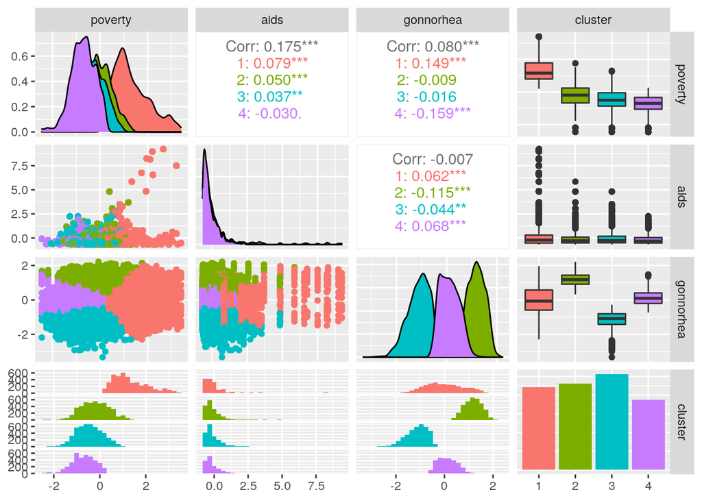

```r
library(GGally)
ggpairs(pamclust, columns = 1:4, aes(color = cluster))
```

```r
# MEANS FOR EACH CLUSTER
pamclust %>% group_by(cluster) %>% summarize_if(is.numeric, mean,
    na.rm = T)
```

```
## # A tibble: 4 x 4
##   cluster poverty    aids gonnorhea
##   <fct>     <dbl>   <dbl>     <dbl>
## 1 1         1.34   0.321    -0.0106
## 2 2        -0.200 -0.113     1.18
## 3 3        -0.453 -0.0573   -1.14
## 4 4        -0.715 -0.162     0.115
```

```r
abortion %>% slice(pam$id.med)
```

```
## # A tibble: 4 x 15
##   stname   age race   year sex   totpop incarcerated crack alcohol income
##   <chr>  <dbl> <chr> <dbl> <chr>  <dbl>        <dbl> <dbl>   <dbl>  <dbl>
## 1 Texas     15 white  1988 male  683117         96.3 1.06     2.47  15325
## 2 Color…    30 black  1989 male   12942        963.  0.923    2.60  18515
## 3 Michi…    30 white  1998 fema… 574649        140.  1.72     2.12  26919
## 4 Rhode…    30 black  2000 fema…   3857        563.  3.12     2.31  29214
## # … with 5 more variables: unemployed <dbl>, poverty <dbl>, repeal <dbl>,
## #   aids <dbl>, gonnorhea <dbl>
```

```r
# GOODNESS-OF-FIT
pam$silinfo$avg.width
```

```
## [1] 0.2083014
```

The variables selected for the cluster analysis were the rates of the stds (aids and gonnorhea) with the poverty rate of the state. Using the generated sihouette plot, the value that maximized the k-value was 4. These variables were then displayed in scatterplot and ggpairs to show the individual correlations. The highest correlation was between AIDS and poverty, however, even this was fairly low at .175. Surprisingly Gonnorhea and AIDS had the lowest correlation and was negatively correlated at -.007. The Goodness-of-fit was 0.2083014 which was pretty low so it was clear that the variables were not well selected for this analysis.

### Dimensionality Reduction with PCA

```r
abortnums <- abortion %>% select_if(is.numeric) %>% select(-repeal) %>%
    scale
abort_pca <- princomp(abortnums, cor = T)
summary(abort_pca, loadings = T)
```

```
## Importance of components:
##                           Comp.1    Comp.2    Comp.3    Comp.4     Comp.5
## Standard deviation     1.6452644 1.4107770 1.2169262 1.1305627 1.01457342
## Proportion of Variance 0.2460813 0.1809356 0.1346281 0.1161975 0.09357811
## Cumulative Proportion  0.2460813 0.4270170 0.5616451 0.6778425 0.77142066
##                            Comp.6     Comp.7    Comp.8     Comp.9    Comp.10
## Standard deviation     0.95187234 0.78832220 0.6218384 0.54795956 0.47835150
## Proportion of Variance 0.08236918 0.05649563 0.0351530 0.02729633 0.02080183
## Cumulative Proportion  0.85378983 0.91028546 0.9454385 0.97273479 0.99353662
##                            Comp.11
## Standard deviation     0.266640462
## Proportion of Variance 0.006463376
## Cumulative Proportion  1.000000000
##
## Loadings:
##              Comp.1 Comp.2 Comp.3 Comp.4 Comp.5 Comp.6 Comp.7 Comp.8 Comp.9
## age                  0.277                0.862  0.157  0.143
## year          0.485        -0.150  0.336        -0.310 -0.148 -0.348 -0.140
## totpop               0.486 -0.114        -0.340  0.119  0.758        -0.135
## incarcerated        -0.541 -0.133  0.212  0.285  0.138  0.455 -0.163 -0.111
## crack         0.308        -0.104        -0.103  0.832 -0.282        -0.321
## alcohol                           -0.810  0.164 -0.192        -0.328 -0.388
## income        0.553        -0.213               -0.146        -0.235  0.236
## unemployed   -0.412        -0.429                0.219        -0.577  0.484
## poverty      -0.357        -0.486  0.320        -0.181 -0.165        -0.600
##              Comp.10 Comp.11
## age           0.333
## year          0.159   0.587
## totpop        0.108
## incarcerated -0.535
## crack
## alcohol
## income        0.197  -0.688
## unemployed            0.110
## poverty       0.109  -0.309
##  [ reached getOption("max.print") -- omitted 2 rows ]
```

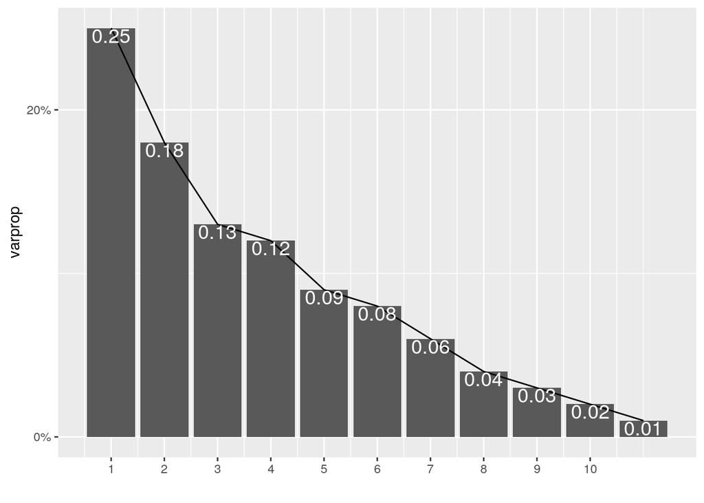

```r
eigval <- abort_pca$sdev^2  #square to convert SDs to eigenvalues
varprop = round(eigval/sum(eigval), 2)  #proportion of var explained by each PC


ggplot() + geom_bar(aes(y = varprop, x = 1:11), stat = "identity") +
    xlab("") + geom_path(aes(y = varprop, x = 1:11)) + geom_text(aes(x = 1:11,
    y = varprop, label = round(varprop, 2)), vjust = 1, col = "white",
    size = 5) + scale_y_continuous(breaks = seq(0, 0.6, 0.2),
    labels = scales::percent) + scale_x_continuous(breaks = 1:10)
```

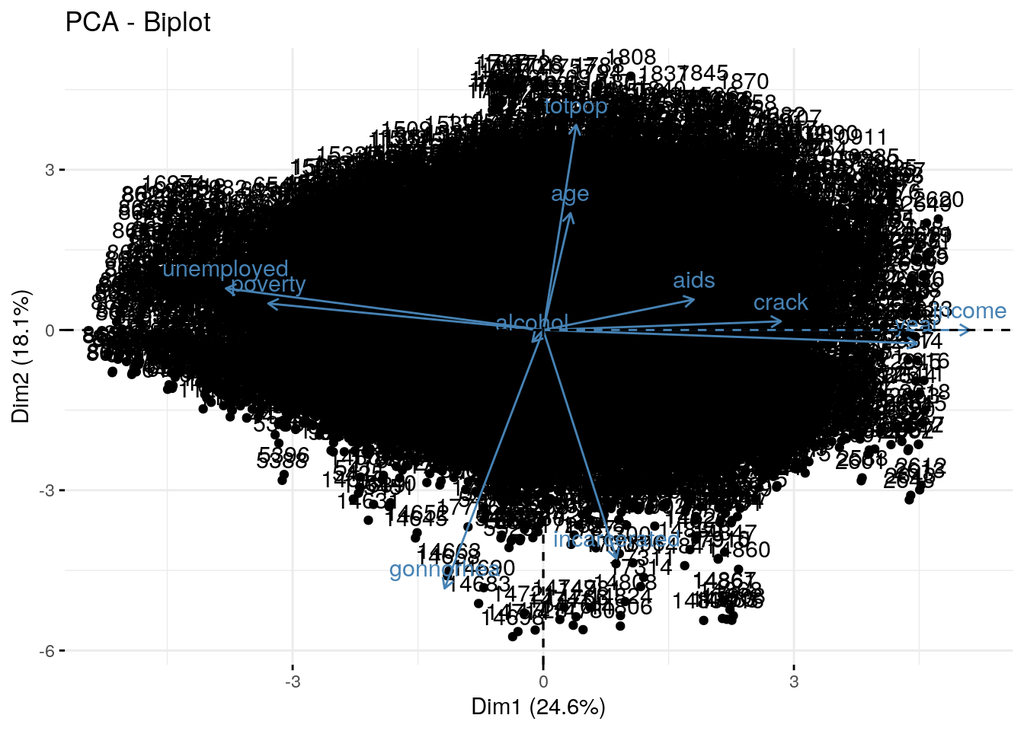

```r
library(factoextra)
fviz_pca_biplot(abort_pca)
```

The PC scores indicate that principle comp 1 accounts for 0.25 variance in the dataset, comp 2 accounts for .18, and comp 3 accounts for .13, etc. To have a total variance of 80% we must include components 1-6. States in the database that score high in component 1 tends to have high income, low unemployment, poverty, and gonnorhea rates. Component 2 has higher population low incarceration and gonnorhea rates and so on (as displayed under loadings). According to the PCA biplot, the arrows represent the variables that have the most in common with each other such as unemployment rate and poverty which correlate negatively with income, crack index and aids rates. total population and age are unrelated to these variables but they are related to the gonnorhea prevalence and incarceration rates.